# Regression and model validation

This week I have worked on linear regression and learned more about how the markdown works. I had not realised that I do not need to start every note or text I write with a #, since I will write the code in chunks which leaves the rest of the script for notes. It felt rewarding to write this code and see the results in the html file. Otherwise I some technical issues colored this week. Firstly, I had some issues with pushing the changes to GitHub which I managed to fix by always starting the new script with adding the personal access token. Secondly, the keyboard of my laptop broke partly resulting to a malfunction of the buttons in the middle of the keyboard. The problem still remains but luckily I managed to dumpster-dive myself a functioning keyboard.

- Describe your work and results clearly.
- Assume the reader has an introductory course level understanding of writing and reading R code as well as statistical methods.
- Assume the reader has no previous knowledge of your data or the more advanced methods you are using.

```r
date()
```

```
## [1] "Mon Nov 14 21:01:48 2022"
```

## Reading the file to R

```r
list.files()
```

```
##  [1] "chapter1.html"
##  [2] "chapter1.Rmd"
##  [3] "chapter2.html"
##  [4] "chapter2.Rmd"
##  [5] "Code_for_fixing_the_connection_to_github.R"
##  [6] "create_learning.R"
##  [7] "data"
##  [8] "data2.csv"
##  [9] "Exercise1.Rmd"
## [10] "Exercise2.Rmd"
## [11] "index.html"
## [12] "index.Rmd"
## [13] "IODS-project.Rproj"
## [14] "README.md"
```

```r
student2014 <- read.csv("data2.csv", header = TRUE, sep = ",")
dim(student2014)
```

```
## [1] 166   7
```

```r
str(student2014)
```

```
## 'data.frame':    166 obs. of  7 variables:
##  $ gender  : chr  "F" "M" "F" "M" ...
##  $ age     : int  53 55 49 53 49 38 50 37 37 42 ...
##  $ attitude: num  3.7 3.1 2.5 3.5 3.7 3.8 3.5 2.9 3.8 2.1 ...
##  $ deep    : num  3.58 2.92 3.5 3.5 3.67 ...
##  $ stra    : num  3.38 2.75 3.62 3.12 3.62 ...
##  $ surf    : num  2.58 3.17 2.25 2.25 2.83 ...
##  $ points  : int  25 12 24 10 22 21 21 31 24 26 ...
```

## Contents of the data

Data is from an international survey of approaches to learning, made possible by teachers. The data is used as a course material in a course called Introduction to Open Data Science and it consists of seven variables and 166 observations.

### Variable contets briefly:

- gender = gender of the respondent (categorical)
- age = age of the respondent (integer)
- attitude = Global attitude toward statistics/10 (numerical)
- deep = mean of the values related to deep learning methods (numerical)
- stra = mean of the values related to strategic learning methods (numerical)
- surf = mean of the values related to surface learning methods (numerical)
- points = exam points (integer)

## Graphic overview of the data

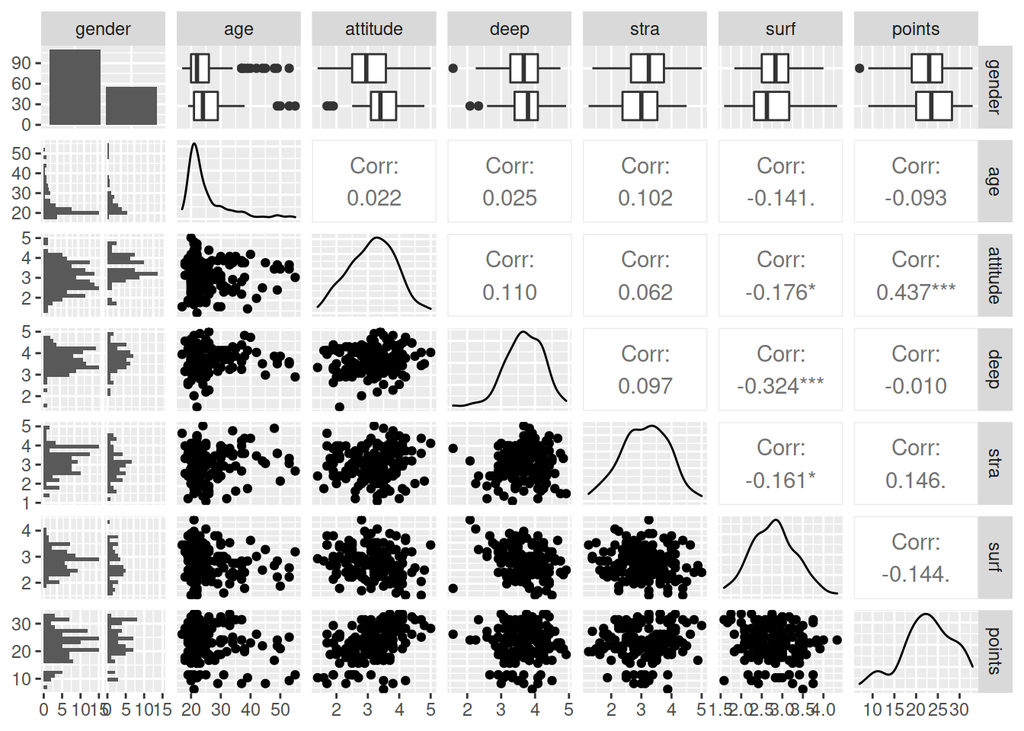

```r
library("ggplot2")
library("GGally")
ggpairs(student2014, lower = list(combo = wrap("facethist", bins = 20)))
```

### Significant correlations from the overview:

- attitude and points (R = 0.437***)
- deep and surf (R = -0.324***)
- stra and surf (R = -0.161*)

### Further focus on pairs with significant correlations and regression lines.

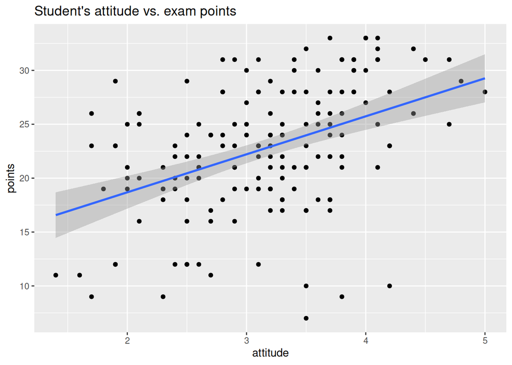

```r
#Access the gglot2 library
library(ggplot2)

# initialize plot with data and aesthetic mapping
p1 <- ggplot(student2014, aes(x = attitude, y = points))+
  geom_point()+
  geom_smooth(method = "lm")+
  ggtitle("Student's attitude vs. exam points")

p1
```

Students that had higher attitude scores obtained also higher exam points.

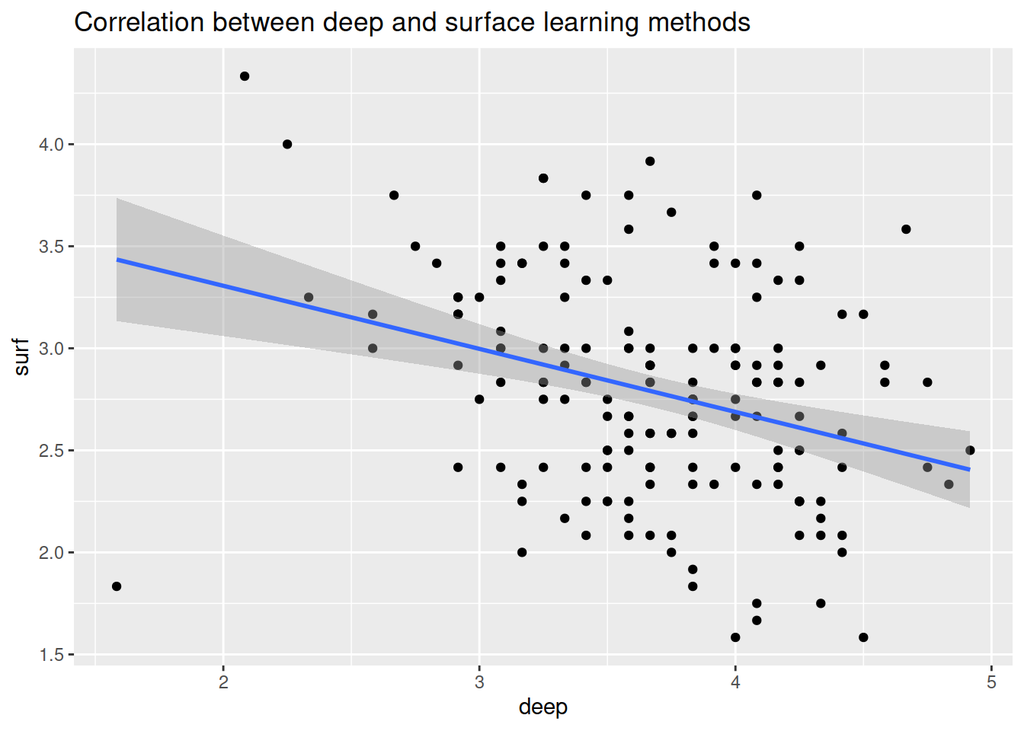

```r
p2 <- ggplot(student2014, aes(x = deep, y = surf))+
  geom_point()+
  geom_smooth(method = "lm")+
  ggtitle("Correlation between deep and surface learning methods")

p2
```

Students that used more surface learning techniques used less likely deep learning techniques.

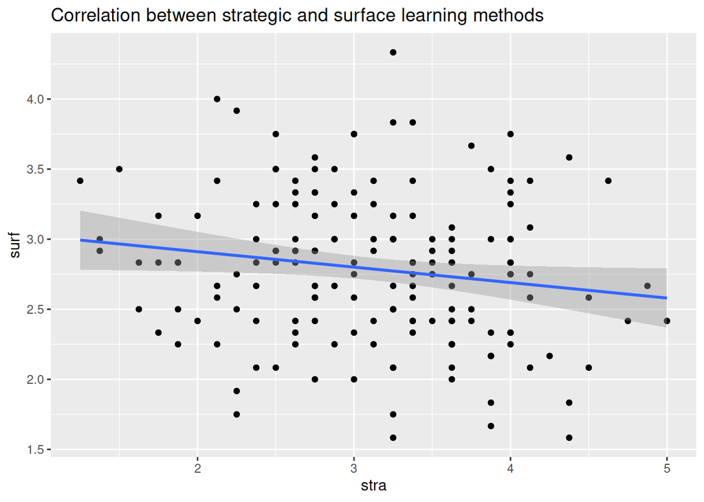

```r
p3 <- ggplot(student2014, aes(x = stra, y = surf))+
  geom_point()+
  geom_smooth(method = "lm")+
  ggtitle("Correlation between strategic and surface learning methods")

p3
```

Students that used surface techniques used strategic techniques less likely.

## Testing the model

```r
my_model <- lm(points ~ attitude + stra + surf + deep, data = student2014)
summary(my_model)
```

```
##
## Call:
## lm(formula = points ~ attitude + stra + surf + deep, data = student2014)
##
## Residuals:
##      Min       1Q   Median       3Q      Max
## -16.7335  -3.1992   0.7975   3.4002  11.6582
##
## Coefficients:
##             Estimate Std. Error t value Pr(>|t|)
## (Intercept)  15.4000     5.0245   3.065  0.00255 **
## attitude      3.4362     0.5739   5.987 1.34e-08 ***
## stra          0.8847     0.5411   1.635  0.10398
## surf         -0.9105     0.8390  -1.085  0.27948
## deep         -1.0072     0.7870  -1.280  0.20247
## ---
## Signif. codes:  0 '***' 0.001 '**' 0.01 '*' 0.05 '.' 0.1 ' ' 1
##
## Residual standard error: 5.286 on 161 degrees of freedom
## Multiple R-squared:  0.2154, Adjusted R-squared:  0.1959
## F-statistic: 11.05 on 4 and 161 DF,  p-value: 6.057e-08
```

Only attitude seems to correlate with the exam points (p = 1.34e-08, p<0.001). To make a model that fits better, I will remove the non-significant variables from the model.

## Removing the excess variables from the model

```r
my_model2 <- lm(points ~ attitude, data = student2014)
summary(my_model2)
```

```
##
## Call:
## lm(formula = points ~ attitude, data = student2014)
##
## Residuals:
##      Min       1Q   Median       3Q      Max
## -16.9763  -3.2119   0.4339   4.1534  10.6645
##
## Coefficients:
##             Estimate Std. Error t value Pr(>|t|)
## (Intercept)  11.6372     1.8303   6.358 1.95e-09 ***
## attitude      3.5255     0.5674   6.214 4.12e-09 ***
## ---
## Signif. codes:  0 '***' 0.001 '**' 0.01 '*' 0.05 '.' 0.1 ' ' 1
##
## Residual standard error: 5.32 on 164 degrees of freedom
## Multiple R-squared:  0.1906, Adjusted R-squared:  0.1856
## F-statistic: 38.61 on 1 and 164 DF,  p-value: 4.119e-09
```

## Assumptions of the model based on diagnostic plots

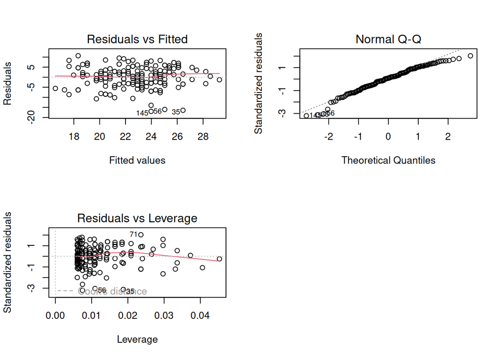

```r
par(mfrow=c(2,2))
plot(my_model2, which = c(1, 2, 5))
```

Residuals vs. leverage provides information on whether there are influential data points that might disturb the model by being for example mistakes in the data. Residuals might be skewed since there is a change in the spread of the values with smaller leverage having higher spread than the ones with higher leverage. When looking at all of the plots, it seems like entries 145, 56 and 35 might be outliers, that should be checked in case of a mistake in the data. Otherwise qq-plot distribution is relatively close to the line. Also the residuals vs. fitted plot looks otherwise good.